# soccer_goal_hypothesis

olayinka ogunneye

2025-09-22

## Introduction

The purpose of this analysis is to test whether **FIFA Women’s World Cup matches** have more goals on average than **FIFA Men’s World Cup matches**, focusing on matches played after January 1, 2002.

We will:

1. Load and inspect the data
2. Filter for relevant matches
3. Create a new variable for total goals per match
4. Explore the data with descriptive statistics and visualizations
5. Conduct a hypothesis test to determine if women’s matches have significantly more goals

### Step 1: Load Required Libraries

```r
library(dplyr)      # for data manipulation
library(lubridate)  # for working with dates
library(ggplot2)    # for visualization
library(here)      # for cleaner file paths
```

### Step 2: Load and Inspect the Data

#### Load the datasets using here()

```r
women <- read.csv(here("data", "raw", "women_results.csv"))
men   <- read.csv(here("data", "raw", "men_results.csv"))

# Check structure
str(women)
```

```
## 'data.frame':    4884 obs. of  7 variables:
##  $ X         : int  0 1 2 3 4 5 6 7 8 9 ...
##  $ date      : chr  "1969-11-01" "1969-11-01" "1969-11-02" "1969-11-02" ...
##  $ home_team : chr  "Italy" "Denmark" "England" "Italy" ...
##  $ away_team : chr  "France" "England" "France" "Denmark" ...
##  $ home_score: int  1 4 2 3 3 0 3 3 3 0 ...
##  $ away_score: int  0 3 0 1 2 2 0 0 0 2 ...
##  $ tournament: chr  "Euro" "Euro" "Euro" "Euro" ...
```

```r
str(men)
```

```
## 'data.frame':    44353 obs. of  7 variables:
##  $ X         : int  0 1 2 3 4 5 6 7 8 9 ...
##  $ date      : chr  "1872-11-30" "1873-03-08" "1874-03-07" "1875-03-06" ...
##  $ home_team : chr  "Scotland" "England" "Scotland" "England" ...
##  $ away_team : chr  "England" "Scotland" "England" "Scotland" ...
##  $ home_score: int  0 4 2 2 3 4 1 0 7 9 ...
##  $ away_score: int  0 2 1 2 0 0 3 2 2 0 ...
##  $ tournament: chr  "Friendly" "Friendly" "Friendly" "Friendly" ...
```

```r
# Peek at the first few rows
head(women)
```

```
##   X       date home_team   away_team home_score away_score       tournament
## 1 0 1969-11-01     Italy      France          1          0             Euro
## 2 1 1969-11-01   Denmark     England          4          3             Euro
## 3 2 1969-11-02   England      France          2          0             Euro
## 4 3 1969-11-02     Italy     Denmark          3          1             Euro
## 5 4 1975-08-25  Thailand   Australia          3          2 AFC Championship
## 6 5 1975-08-25 Hong Kong New Zealand          0          2 AFC Championship
```

```r
head(men)
```

```
##   X       date home_team away_team home_score away_score tournament
## 1 0 1872-11-30  Scotland   England          0          0   Friendly
## 2 1 1873-03-08   England  Scotland          4          2   Friendly
## 3 2 1874-03-07  Scotland   England          2          1   Friendly
## 4 3 1875-03-06   England  Scotland          2          2   Friendly
## 5 4 1876-03-04  Scotland   England          3          0   Friendly
## 6 5 1876-03-25  Scotland     Wales          4          0   Friendly
```

str() shows the structure of the dataset (columns, types, etc.).

head() previews the first rows to confirm the data looks correct

We only want official FIFA World Cup matches (not qualifiers or friendlies), and only those played after January 1, 2002.

```r
# Filter women's FIFA World Cup matches
women_wc <- women %>%
  filter(tournament == "FIFA World Cup", date >= as.Date("2002-01-01"))

# Filter men's FIFA World Cup matches
men_wc <- men %>%
  filter(tournament == "FIFA World Cup", date >= as.Date("2002-01-01"))
```

#### Explanation:

keeps only rows meeting both conditions: tournament type and date.

ensures the date is treated as a proper date object.

### Step 4: Create Total Goals Column

We add a new column that sums the home and away team scores for each match.

```r
women_wc <- women_wc %>%
  mutate(total_goals = home_score + away_score)

men_wc <- men_wc %>%
  mutate(total_goals = home_score + away_score)
```

#### Explanation:

creates a new variable.

gives the total goals scored in each match

```r
# Summary statistics
summary(women_wc$total_goals)
```

```
##    Min. 1st Qu.  Median    Mean 3rd Qu.    Max.
##    0.00    2.00    3.00    2.98    4.00   13.00
```

```r
summary(men_wc$total_goals)
```

```
##    Min. 1st Qu.  Median    Mean 3rd Qu.    Max.
##   0.000   1.000   2.000   2.513   3.000   8.000
```

```r
# Standard deviation
sd(women_wc$total_goals)
```

```
## [1] 2.022387
```

```r
sd(men_wc$total_goals)
```

```
## [1] 1.652544
```

#### Explanation:

gives min, quartiles, median, mean, and max.

measures variability in goals per match

### Histogram Comparison

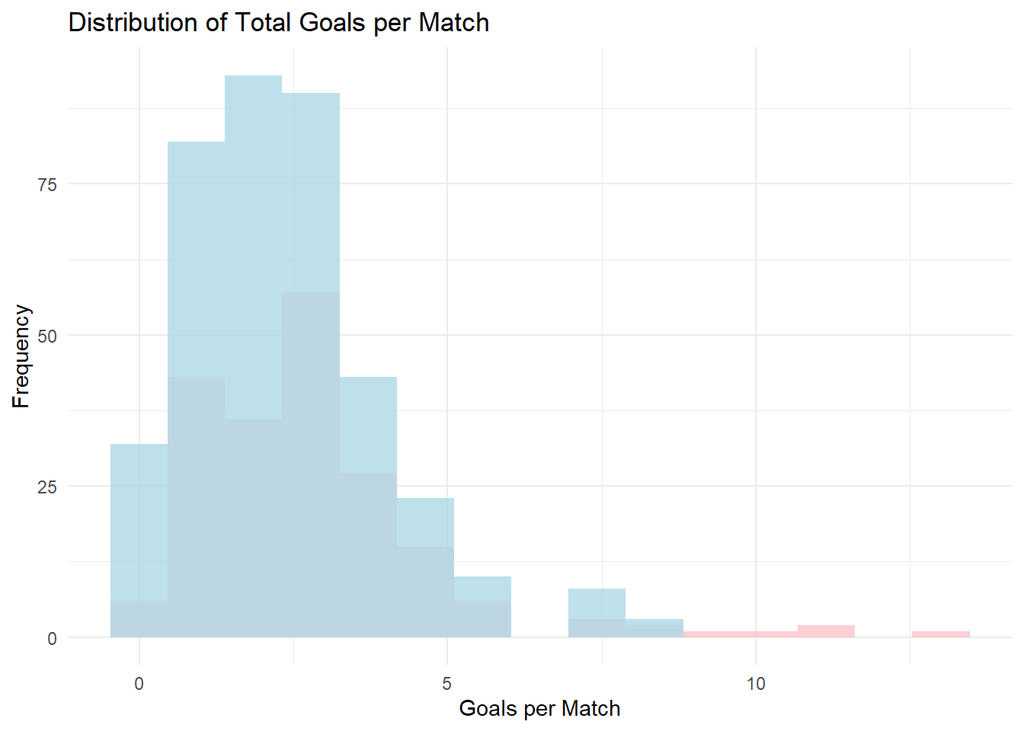

```r
ggplot() +
  geom_histogram(data = women_wc, aes(x = total_goals),
                 fill = "pink", alpha = 0.8, bins = 15) +
  geom_histogram(data = men_wc, aes(x = total_goals),
                 fill = "lightblue", alpha = 0.8, bins = 15) +
  labs(title = "Distribution of Total Goals per Match",
       x = "Goals per Match", y = "Frequency") +
  theme_minimal()
```

#### Explanation:

Overlaid histograms show how the distributions of goals differ between men’s and women’s matches.

### Boxplot Comparison

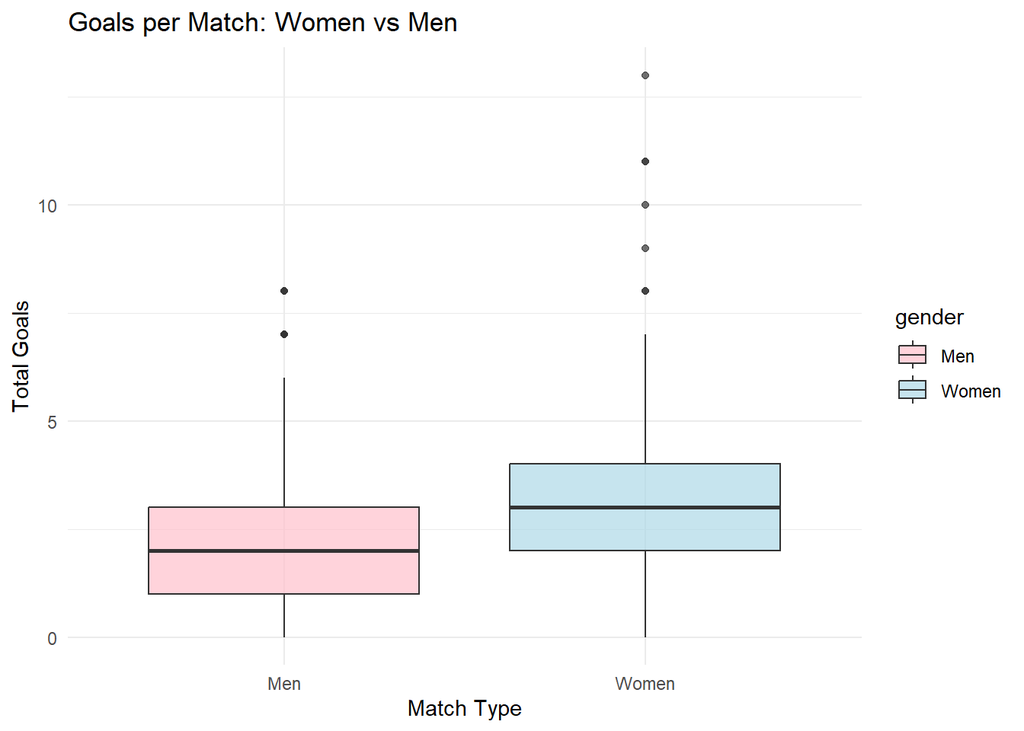

```r
combined <- bind_rows(
  women_wc %>% select(total_goals) %>% mutate(gender = "Women"),
  men_wc %>% select(total_goals) %>% mutate(gender = "Men")
)

ggplot(combined, aes(x = gender, y = total_goals, fill = gender)) +
  geom_boxplot(alpha = 0.7) +
  labs(title = "Goals per Match: Women vs Men",
       x = "Match Type", y = "Total Goals") +
  scale_fill_manual(values = c("pink", "lightblue")) +
  theme_minimal()
```

### Explanation:

Boxplots highlight medians, interquartile ranges, and outliers.

Women’s matches show a higher median and more variability

### Step 6: Hypothesis Test

We now formally test whether women’s matches have more goals than men’s.

This is a one-tailed Welch’s t-test.

```r
t_test_result <- t.test(
  women_wc$total_goals,
  men_wc$total_goals,
  alternative = "greater",   # one-tailed: women > men
  var.equal = FALSE          # Welch's t-test (doesn't assume equal variance)
)

t_test_result
```

```
##
##  Welch Two Sample t-test
##
## data:  women_wc$total_goals and men_wc$total_goals
## t = 2.8128, df = 340.1, p-value = 0.002598
## alternative hypothesis: true difference in means is greater than 0
## 95 percent confidence interval:
##  0.193158      Inf
## sample estimates:
## mean of x mean of y
##  2.980000  2.513021
```

#### Explanation:

tests if women’s matches have a higher mean.

uses Welch’s correction, which is safer when variances differ.

The output gives the t-statistic, degrees of freedom, p-value, and confidence interval.

## Conclusion

**Women’s matches average nearly 3 goals per game, compared to 2.5 for men’s.**

**The t-test p-value is 0.0026, well below the 10% significance level.**

**We reject the null hypothesis and conclude that women’s World Cup matches have significantly more goals on average than men’s.**